# Homework 6

Bob Bartolini

9/18/2020

Inference and Likelihood!

https://github.com/rjmaitri/Inference-and-Likelihood.git

```r
library(dplyr)
library(tidyverse)
library(profileModel)
library(ggplot2)
```

### Go through the faded examples in the lab. You don’t need to put the output here - just, do them! And let us know if you have any remaining questions, or you feel comfortable. Full credit!

fat <- read.csv(“../data/17q04BodyFatHeatLoss Sloan and Keatinge 1973 replica.csv”)

initial visualization to determine if lm is appropriate fat_plot <- ggplot(data=fat, aes(x=leanness, y=lossrate)) + geom_point() fat_plot

#fit that model fat_mod <- glm(lossrate ~ leanness, family = gaussian(link = “identity”), data=fat)

#assumptions fat_fit <- predict(fat_mod) fat_res <- residuals(fat_mod)

qplot(fat_fit, fat_res)

qqnorm(fat_res) qqline(fat_res)

plot(profile(fat_mod))

#LRT test of model fat_mod_null <- glm(lossrate ~ 1, family = gaussian(link = “identity”), data=fat)

anova(fat_mod_null, fat_mod, test = “LRT”)

#t-tests of parameters summary(fat_mod)

deet <- read.csv(“../data/17q24DEETMosquiteBites.csv”)

deet_plot <- ggplot(data=deet, aes(x=dose, y=bites)) + geom_point()

deet_plot

#fit that model deet_mod <- glm(bites ~ dose, family = gaussian(link = “identity”) data=deet)

#assumptions deet_fit <- predict(deet_mod) deet_res <- residuals(deet_mod)

qplot(deet_fit, deet_res)

qqnorm(deet_res) qqline(deet_res)

plot(profile(deet_mod))

#f-tests of model deet_mod_null <- glm(bites ~ dose, family = gaussian(link = “identity”) data=deet)

anova(deet_mod_null, deet_mod, test = “LRT”)

#t-tests of parameters summary(deet_mod)

zoo <- read.csv(“../data/17q02ZooMortality Clubb and Mason 2003 replica.csv”)

zoo_plot <- ggplot(data=zoo, aes(x=mortality, y=homerange)) + geom_point()

#fit that model zoo_mod <- glm(homerange~mortality, family = gaussian(link = “identity”), data = zoo)

#assumptions zoo_fit <- predict(zoo_mod) zoo_res <- residuals(zoo_mod)

qplot(zoo_fit, zoo_res)

qqnorm(zoo_res) qqline(zoo_res)

plot(profile(zoo_mod))

#LRT-tests of model zoo_mod_null <- <- glm(homerange~ 1, family = gaussian(link = “identity”), data = zoo)

anova(zoo_mod_null, zoo_mod, test = “LRT”)

#z-tests of parameters summary(zoo_mod)

### Would you say you naturally gravitate towards deductive or inductive inference? Why?

The context of the problem decides if I will use a deductive or inductive approach. For example, when my car breaks down, I have a deductive approach, starting with the general systems and narrowing down to the specific malfunctioning part. However, I tend to make inductive inferences when I analyze basic research datasets. A heatmap I generated using iPOND (isolated protein on nascent DNA) data showed upregulation within a set of genes specific to a certain DNA repair pathway. Deriving inference on the repair pathway from protein abundance data is an example of inductive inference, as a specific detail led me to a more general observation.

### We talked about strictly interpreted Popperian Flasification versus Lakatos’s view of a research program this week.

## 2a. Do you more strongly identify with one of these paradigms? Why? +1 EC for direct quotes (if you want to do some additional reading)

Popper Debunking pseudo-science and supporting deterministic relationships are the only areas where I’d chose Poppers over Lakatos. Poppers rugged skepticism is useful in a world that is rife with superstitous beliefs. Popper’s philosophical assertion that a theory can never be proven to be true, since the next test can falsify it is a powerful approach to debunking errorneous claims. However, the approach seems overly pragmatic for fields that are beyond the realm of empirical testing, such as astrophysics. For example, Popper said Neils Bohr was “a marvelous physicist, one of the greatest of all time, but he was a miserable philosopher”. This quote emphasizes that Popper held no respect for inductive reasoning that fell beyong his epistemological boundaries. I find this approach to be overtly cautious and may limit scientific minds that dare to explore the edges of unknown fields. Einsteins Theory of General Relativity lacked empirical evidence during his time, however, they have been supported by rare astronomical events, such as observing a star orbiting a supermassive blackhole, that occured long after Einsteins death.

Lakatos Imre Lakatos approach to deductive inference. The gravitational theories by Einstein are a great example of this. As Einstein began with a core theory of Newtonian gravity, he began to develop auxilliary hypothesis in the form of thought experiments, which ultimately placed him in a position to develop theories involving the effects of black holes. Modern telescopes are just able to confirm these theories. This is an example of Lakato’s view of a research program building outwards from a core theory that is not falsifiable. Had modern telescopy falsified Einstein’s claims n the effects of blackholes, it would be an example of a degenerating theory.

## 2b. How does your own research program fit into one of these paradigms?

I currently research how to identify differentially expressed genes between diseased and healthy tissue samples. Preparing samples, quantifying transcript abundance and statisical analysis gives insight into a diseased cells expression profile. This is basic research that spurs auxiliary hypotheses, therefore this work echos Imre Lakatos research program.

###Puffers! ## Let’s look at the pufferfish data with likelihood!

3. Grid Sampling! Based on Friday’s lab, load up the pufferfish data and use grid sampling to find the MLE of the slope, intercept and residual SD of this model. Feel free to eyeball results from an lm() fit to get reasonable values. Try not to do this for a grid of more than ~100K points (more if you want!). It’s ok to be coarse. Compare to lm.

```r
#Load the data
puff_fish <- read.csv("data/16q11PufferfishMimicry Caley & Schluter 2003.csv")

#Peek into the file
str(puff_fish)
```

```
## 'data.frame':    20 obs. of  2 variables:
##  $ resemblance: int  1 1 1 1 1 1 1 2 2 2 ...
##  $ predators  : int  2 6 5 5 0 3 11 6 8 11 ...
```

```r
summary(puff_fish)
```

```
##   resemblance     predators
##  Min.   :1.00   Min.   : 0.00
##  1st Qu.:1.00   1st Qu.: 5.75
##  Median :2.00   Median :10.00
##  Mean   :2.35   Mean   : 8.95
##  3rd Qu.:3.25   3rd Qu.:11.00
##  Max.   :4.00   Max.   :18.00
```

```r
#Fit a model
puffer_LM <- lm(predators ~ resemblance, data = puff_fish)

puffer_LM
```

```
##
## Call:
## lm(formula = predators ~ resemblance, data = puff_fish)
##
## Coefficients:
## (Intercept)  resemblance
##       1.925        2.989
```

I will refer to these coefficients for the grid sampling

```r
#look into the residual sd
sd(puffer_LM[["residuals"]])
```

```
## [1] 2.971769
```

This will be used for the grid sampling.

```r
############likelihood with grid sampling #################################
norm_likelihood <- function(obs, B0, B1, sd){

  #data generating process (uses crossing variable names in y-hat equation)
  est <- puff_fish$resemblance  * B1 + B0

  #log likelihood fnction
  sum(dnorm(obs, mean = est, sd = sd, log = TRUE))

#  likelihoods <- dnorm(puff_fish$predators, mean = puff_fish$resemblance  * B1 + B0, sd = err.sigma)

}

puff_dist <- crossing(Slope = seq(2.75, 3.25, by = 0.01),
                      Int =seq(1.75, 2.15, by = 0.01),
                      res_sd = seq(2.5,3.5, by = 0.01)) %>%
  rowwise() %>%
  mutate(log_lik = norm_likelihood(obs = puff_fish$predators, B0 = Int, B1 = Slope, sd = res_sd)) %>%
  ungroup()
```

```r
puff_dist %>%
  filter(log_lik == max(log_lik))
```

| Slope | Int | res_sd | log_lik |
| --- | --- | --- | --- |
| 2.99 | 1.92 | 2.9 | -49.64903 |

The function and grid sampling give us a MLE for the slope, int and res_sd, this is virtually the same as the LM output.

4. Surfaces! Filter the dataset to the MLE of the SD. Plot the surface for the slope and intercept in whatever way you find most compelling. You might want to play around with zooming in to different regions, etc. Have fun!

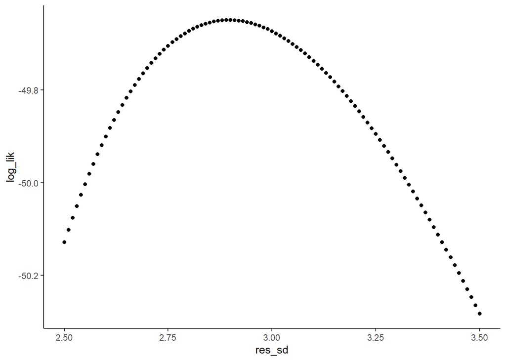

```r
#Likelihood surface!
#'
#Filter to MLE of SD
sd_MLE <-  puff_dist %>%
  group_by(res_sd) %>%
  filter(log_lik == max(log_lik)) %>%
  ungroup()

#Profile for SD
ggplot(sd_MLE, aes(x= res_sd, y= log_lik)) +
  geom_point()+
  theme_classic()
```

```r
###lets look at the CI
sd_MLE %>%
  filter(log_lik > max(log_lik) - 1.92) %>%
    filter(row_number()==1 | row_number()==n())
```

| Slope | Int | res_sd | log_lik |
| --- | --- | --- | --- |
| 2.99 | 1.92 | 2.5 | -50.12835 |
| 2.99 | 1.92 | 3.5 | -50.28289 |

```r
#surface of slope and intercept

slopIntraster <- ggplot(data = puff_dist,
mapping = aes(x = Slope, y = Int, fill = log_lik)) +
geom_raster() +
scale_fill_viridis_c()



IntSlope <-  ggplot(data = puff_dist %>% filter(log_lik > max(log_lik)-5),
mapping = aes(x = Slope, y = Int, fill = log_lik)) +
geom_raster() +
scale_fill_viridis_c()

rayshader::plot_gg(IntSlope)
```

[output not shown]

Note: The surface ouputs in rstudiob but not in the rmd html file.

5. GLM! Now, compare those results to results from glm. Show the profiles and confidence intervals from glm() for the slope and intercept. Also show how you validate assumptions.

```r
#fit the generalized lin
puffer_mle <- glm(predators ~ resemblance,
                family = gaussian(link = "identity"),
                data = puff_fish)

puffer_mle
```

```
##
## Call:  glm(formula = predators ~ resemblance, family = gaussian(link = "identity"),
##     data = puff_fish)
##
## Coefficients:
## (Intercept)  resemblance
##       1.925        2.989
##
## Degrees of Freedom: 19 Total (i.e. Null);  18 Residual
## Null Deviance:       423
## Residual Deviance: 167.8     AIC: 105.3
```

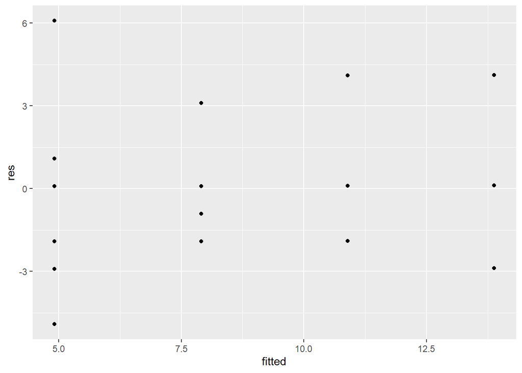

```r
#Test assumptions
#No relationship between fitted and residual values
fitted <- predict(puffer_mle)
res <- residuals(puffer_mle)

qplot(fitted, res)
```

Residuals vs. fitted upholds the assumption of no relationship, shown by the scattered data.

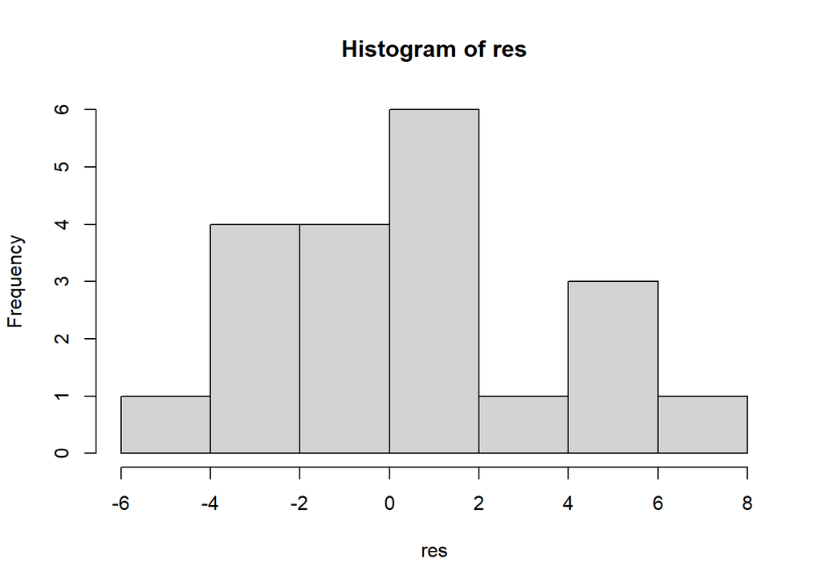

```r
#Residuals follow normal distribution

hist(res)
```

The residuals uphold the assumption of normality.

```r
#compare CI of GLM to CI likelihood/crossing function
prof <- profileModel(puffer_mle,
                     objective = "ordinaryDeviance",
                     quantile = qchisq(0.95,1))
```

```
## Preliminary iteration .. Done
##
## Profiling for parameter (Intercept) ... Done
## Profiling for parameter resemblance ... Done
```

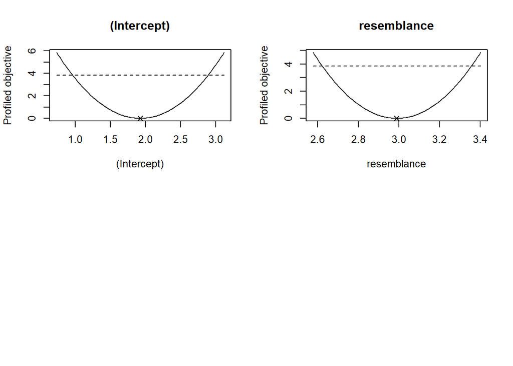

```r
plot(prof)
```